# Predicting the number of wins and playoff contention in the National Football league

## Chase Lampert

Intro: Team data from the National Football League from the years 2010 through 2016 will be used alongside some data science principles to try to predict the number of wins in a season for an NFL team. We will also try and predict if a team will be in playoff contention. The NFL is an economic giant, producing over 10 billion dollars in 2016 revenue. Data science can be a key an integral part of predicting which teams will perform well as well as individual games. If a person were to make an accurate enough model they would be in a very advantageous position. This is one reason to learn more about the potential of data science and the NFL in this tutorial.

Tools: Python 3 Libraries: Pandas, numpy, matplotlib, scikit-learn

dataset: http://static.pfref.com/years/

#### Concentrating the data into one table:

This website provides the nessesary data, but it is all in seperate tables. The link above brings you to a web page where it lists the years on the left hand side. Start by clicking on the year 2016 (the 2017 season is not complete). Under the header "AFC standings" click on the "share and more tab" this opens a drop down menu, click on "get table as csv". The format of the table changes from a table to a csv, highlight the table and copy it. Paste the table into a text editor. Repeat this proccess for "NFC standings". After you have gotten both the AFC and NFC table, repeat this proccess for the years 2015 though 2010, pasting all of the CSV tables into the same text editor page. Once you have years 2010 through 2016 in a text editor, go into the text editor, use the find and replace tool to replace all commas with tab's (\t). Then copy everything in the text editor and paste it into either a numbers table if you're on a mac or an excel table if you are on another machine. Then download the table as a CSV and upload it into the same directory as your python project.

#### Explaining the data:

Tm: The NFL team that this row's data belongs to W: The number of wins out of 16 for that team during that season. L: The number of losses out of 16 for that team during that season. T: The number of ties out of 16 for that team during that season. W-L%: Win loss percentage for that team during that season. PF: Point for, the total number of points scored. PA: Points allowed, the total number of points allowed. PD: Point differential, the difference between points for and points allowed. MoV: Margin of Victory, the average amount of points a team won or lost by. SoS: Strength of Schedule, the average quality of opponent based on SRS SRS: Simple Rating System, the teams quality relative to the average (0.0) OSRS: Offensive Simple Rating System, the team's offensive quality relative to the average (0.0) DSDS: Defensive Simple Rating System, the teams defensive quality relative to the average (0.0)

#### Documentation of used python libraries

```
 Pandas: https://pandas.pydata.org/pandas-docs/stable/10min.html
 numpy: https://docs.scipy.org/doc/numpy-dev/user/quickstart.html
 Matplotlib: https://matplotlib.org/users/intro.html
 sklearn: http://scikit-learn.org/stable/tutorial/basic/tutorial.html
```

```python
import pandas as pd
import numpy as np
import matplotlib.pyplot as plt
import statsmodels.api as sm
from sklearn import preprocessing,svm
#from sklearn.preprocessing import StandardScaler
from sklearn import model_selection,metrics
from sklearn.linear_model import LinearRegression
from sklearn.model_selection import train_test_split,cross_val_score,cross_val_predict
from sklearn.naive_bayes import GaussianNB
from sklearn.metrics import accuracy_score
import warnings
warnings.filterwarnings('ignore')
```

```python
#read in the dataset using pandas
df = pd.read_csv('datanfl.csv')
# call the first 5 rows of the data frame
df.head()
```

|  | Unnamed: 0 | Unnamed: 1 | Unnamed: 2 | Unnamed: 3 | Unnamed: 4 | Unnamed: 5 | Unnamed: 6 | Unnamed: 7 | Unnamed: 8 | Unnamed: 9 | Unnamed: 10 | Unnamed: 11 | Unnamed: 12 | Unnamed: 13 |
| --- | --- | --- | --- | --- | --- | --- | --- | --- | --- | --- | --- | --- | --- | --- |
| 0 | NaN | Tm | W | L | T | W-L% | PF | PA | PD | MoV | SoS | SRS | OSRS | DSRS |
| 1 | NaN | New England Patriots* | 14 | 2 | 0 | 0.875 | 441 | 250 | 191 | 11.9 | -2.7 | 9.3 | 4.3 | 5.0 |
| 2 | NaN | Miami Dolphins+ | 10 | 6 | 0 | 0.625 | 363 | 380 | -17 | -1.1 | -1.3 | -2.4 | -0.6 | -1.8 |
| 3 | NaN | Buffalo Bills | 7 | 9 | 0 | 0.438 | 399 | 378 | 21 | 1.3 | -1.6 | -0.3 | 1.8 | -2.2 |
| 4 | NaN | New York Jets | 5 | 11 | 0 | 0.313 | 275 | 409 | -134 | -8.4 | -0.1 | -8.5 | -5.5 | -3.0 |

## Tidying the data

```
1) The entire first column is NaN values, drop it from the data frame. Column names were treated as the first row of values. Change the column names to these values then drop the first row.
```

```python
# drop the first column entirly
df = df.drop(['Unnamed: 0'], axis=1)
# Change the name of the columns to the values of the first row in the dataframe
df.columns = ['Tm', 'W', 'L','T', 'W-L%', 'PF','PA','PD', 'MoV','SoS','SRS','OSRS','DSRS']
# remove the first row from the dataframe
df = df.drop([0])
```

```python
display(df.head())
display(df.tail())
```

|  | Tm | W | L | T | W-L% | PF | PA | PD | MoV | SoS | SRS | OSRS | DSRS |
| --- | --- | --- | --- | --- | --- | --- | --- | --- | --- | --- | --- | --- | --- |
| 1 | New England Patriots* | 14 | 2 | 0 | 0.875 | 441 | 250 | 191 | 11.9 | -2.7 | 9.3 | 4.3 | 5.0 |
| 2 | Miami Dolphins+ | 10 | 6 | 0 | 0.625 | 363 | 380 | -17 | -1.1 | -1.3 | -2.4 | -0.6 | -1.8 |
| 3 | Buffalo Bills | 7 | 9 | 0 | 0.438 | 399 | 378 | 21 | 1.3 | -1.6 | -0.3 | 1.8 | -2.2 |
| 4 | New York Jets | 5 | 11 | 0 | 0.313 | 275 | 409 | -134 | -8.4 | -0.1 | -8.5 | -5.5 | -3.0 |
| 5 | Pittsburgh Steelers* | 11 | 5 | 0 | 0.688 | 399 | 327 | 72 | 4.5 | 0.2 | 4.7 | 2.8 | 2.0 |

|  | Tm | W | L | T | W-L% | PF | PA | PD | MoV | SoS | SRS | OSRS | DSRS |
| --- | --- | --- | --- | --- | --- | --- | --- | --- | --- | --- | --- | --- | --- |
| 221 | Seattle Seahawks* | 7 | 9 | 0.438 | 310 | 407 | -97 | -6.1 | -3.4 | -9.4 | -3.9 | -5.5 | NaN |
| 222 | St. Louis Rams | 7 | 9 | 0.438 | 289 | 328 | -39 | -2.4 | -4.2 | -6.7 | -6.3 | -0.4 | NaN |
| 223 | San Francisco 49ers | 6 | 10 | 0.375 | 305 | 346 | -41 | -2.6 | -3.3 | -5.8 | -4.7 | -1.1 | NaN |
| 224 | Arizona Cardinals | 5 | 11 | 0.313 | 289 | 434 | -145 | -9.1 | -3.6 | -12.7 | -5.6 | -7.1 | NaN |
| 225 | NaN | NaN | NaN | NaN | NaN | NaN | NaN | NaN | NaN | NaN | NaN | NaN | NaN |

There are still issues with the data. First there is an extra row where all of the values are NaN we can outright drop this row. Next we see that the DSRS value is NaN for the tail of our dataframe. This comes from when we curated our data. In years such as 2010, which is represented in the tail, there were no ties - thus the T column was not put into those tables. When we copy and pasted our data we did not take this into account. This means that for season in which there were on ties every column from W-L% and right is shifted to the left one column. To clean this data we will traverse through the entire dataframe and if DSRS is NaN then shift all values from column T on to the right one and set T equal to 0.

```python
df = df.drop(225)
for idx,row in df.iterrows():
    # if DSRS is a float then the value must be NaN (all other values are in the form of a string)
    if(isinstance(row['DSRS'],float)):
        # get the value of T column which actually corresponds to the W-L%
        val = row[3]
        row = row.set_value('T', 0)
        # for all columns 'T' - 'DSRS' shift the value to the right one and store the current value there as a temp
        for i in range(4,13):
            col = df.columns[i]
            val2 = row[i]
            row = row.set_value(col, val)
            val = val2
        # set the current row to new row with T=0 and the other values shifted to the right
        df.iloc[idx-1] = row
```

```python
df.tail()
```

|  | Tm | W | L | T | W-L% | PF | PA | PD | MoV | SoS | SRS | OSRS | DSRS |
| --- | --- | --- | --- | --- | --- | --- | --- | --- | --- | --- | --- | --- | --- |
| 220 | Carolina Panthers | 2 | 14 | 0 | 0.125 | 196 | 408 | -212 | -13.3 | 0.1 | -13.2 | -9.1 | -4.1 |
| 221 | Seattle Seahawks* | 7 | 9 | 0 | 0.438 | 310 | 407 | -97 | -6.1 | -3.4 | -9.4 | -3.9 | -5.5 |
| 222 | St. Louis Rams | 7 | 9 | 0 | 0.438 | 289 | 328 | -39 | -2.4 | -4.2 | -6.7 | -6.3 | -0.4 |
| 223 | San Francisco 49ers | 6 | 10 | 0 | 0.375 | 305 | 346 | -41 | -2.6 | -3.3 | -5.8 | -4.7 | -1.1 |
| 224 | Arizona Cardinals | 5 | 11 | 0 | 0.313 | 289 | 434 | -145 | -9.1 | -3.6 | -12.7 | -5.6 | -7.1 |

```python
# the type of the W column is a string
type(df['W'][1])
```

```
str
```

The W column is currently being treated as a String, as are all of the columns to its right. Those numbers are meant to be floats. In the next code box set all of the columns from W on to being treated as floats.

```python
for i in range(1,13):
    col = df.columns[i]
    df[col] = df[col].apply(float)
type(df['W'][1])
```

```
numpy.float64
```

```python
# convert PF and PA columns to average per game for later analysis
df['PF'] = df['PF']/16
df['PA'] = df['PA']/16
df.head()
```

|  | Tm | W | L | T | W-L% | PF | PA | PD | MoV | SoS | SRS | OSRS | DSRS |
| --- | --- | --- | --- | --- | --- | --- | --- | --- | --- | --- | --- | --- | --- |
| 1 | New England Patriots* | 14.0 | 2.0 | 0.0 | 0.875 | 27.5625 | 15.6250 | 191.0 | 11.9 | -2.7 | 9.3 | 4.3 | 5.0 |
| 2 | Miami Dolphins+ | 10.0 | 6.0 | 0.0 | 0.625 | 22.6875 | 23.7500 | -17.0 | -1.1 | -1.3 | -2.4 | -0.6 | -1.8 |
| 3 | Buffalo Bills | 7.0 | 9.0 | 0.0 | 0.438 | 24.9375 | 23.6250 | 21.0 | 1.3 | -1.6 | -0.3 | 1.8 | -2.2 |
| 4 | New York Jets | 5.0 | 11.0 | 0.0 | 0.313 | 17.1875 | 25.5625 | -134.0 | -8.4 | -0.1 | -8.5 | -5.5 | -3.0 |
| 5 | Pittsburgh Steelers* | 11.0 | 5.0 | 0.0 | 0.688 | 24.9375 | 20.4375 | 72.0 | 4.5 | 0.2 | 4.7 | 2.8 | 2.0 |

There are 32 teams in the NFL and the data is in order by season with the 2016 seasons first, followed by the 2015 season and so on until the 2010 season. Thus we can cut our data frame into bins of 32 and end up with 7 equal bins that represent the year.

```python
df['year'] = 0
df2 = np.array_split(df, 7)
year = 2016
frames = []
idx = 0
for df in df2:
    df['year'] = year
    year = year-1
    frames.insert(idx,df)
    idx = idx+1
df = pd.concat(frames)
```

```python
display(df.head(n=3))
display(df[32:35])
display(df[64:67])
display(df[97:100])
display(df[132:135])
display(df[166:169])
display(df[200:203])
# new column year has been added and accuratly depicts which year a row's values are from
```

|  | Tm | W | L | T | W-L% | PF | PA | PD | MoV | SoS | SRS | OSRS | DSRS | year |
| --- | --- | --- | --- | --- | --- | --- | --- | --- | --- | --- | --- | --- | --- | --- |
| 1 | New England Patriots* | 14.0 | 2.0 | 0.0 | 0.875 | 27.5625 | 15.625 | 191.0 | 11.9 | -2.7 | 9.3 | 4.3 | 5.0 | 2016 |
| 2 | Miami Dolphins+ | 10.0 | 6.0 | 0.0 | 0.625 | 22.6875 | 23.750 | -17.0 | -1.1 | -1.3 | -2.4 | -0.6 | -1.8 | 2016 |
| 3 | Buffalo Bills | 7.0 | 9.0 | 0.0 | 0.438 | 24.9375 | 23.625 | 21.0 | 1.3 | -1.6 | -0.3 | 1.8 | -2.2 | 2016 |

|  | Tm | W | L | T | W-L% | PF | PA | PD | MoV | SoS | SRS | OSRS | DSRS | year |
| --- | --- | --- | --- | --- | --- | --- | --- | --- | --- | --- | --- | --- | --- | --- |
| 33 | New England Patriots* | 12.0 | 4.0 | 0.0 | 0.750 | 29.0625 | 19.6875 | 150.0 | 9.4 | -2.4 | 7.0 | 5.3 | 1.7 | 2015 |
| 34 | New York Jets | 10.0 | 6.0 | 0.0 | 0.625 | 24.1875 | 19.6250 | 73.0 | 4.6 | -3.0 | 1.5 | -0.5 | 2.0 | 2015 |
| 35 | Buffalo Bills | 8.0 | 8.0 | 0.0 | 0.500 | 23.6875 | 22.4375 | 20.0 | 1.3 | -1.2 | 0.0 | 0.3 | -0.2 | 2015 |

|  | Tm | W | L | T | W-L% | PF | PA | PD | MoV | SoS | SRS | OSRS | DSRS | year |
| --- | --- | --- | --- | --- | --- | --- | --- | --- | --- | --- | --- | --- | --- | --- |
| 65 | New England Patriots* | 12.0 | 4.0 | 0.0 | 0.750 | 29.2500 | 19.5625 | 155.0 | 9.7 | 1.3 | 10.9 | 7.5 | 3.5 | 2014 |
| 66 | Buffalo Bills | 9.0 | 7.0 | 0.0 | 0.563 | 21.4375 | 18.0625 | 54.0 | 3.4 | 1.6 | 4.9 | -0.4 | 5.3 | 2014 |
| 67 | Miami Dolphins | 8.0 | 8.0 | 0.0 | 0.500 | 24.2500 | 23.3125 | 15.0 | 0.9 | 1.6 | 2.6 | 2.9 | -0.4 | 2014 |

|  | Tm | W | L | T | W-L% | PF | PA | PD | MoV | SoS | SRS | OSRS | DSRS | year |
| --- | --- | --- | --- | --- | --- | --- | --- | --- | --- | --- | --- | --- | --- | --- |
| 98 | New York Jets | 8.0 | 8.0 | 0.0 | 0.500 | 18.1250 | 24.1875 | -97.0 | -6.1 | 0.0 | -6.1 | -4.7 | -1.4 | 2013 |
| 99 | Miami Dolphins | 8.0 | 8.0 | 0.0 | 0.500 | 19.8125 | 20.9375 | -18.0 | -1.1 | 0.3 | -0.8 | -2.9 | 2.1 | 2013 |
| 100 | Buffalo Bills | 6.0 | 10.0 | 0.0 | 0.375 | 21.1875 | 24.2500 | -49.0 | -3.1 | -0.1 | -3.2 | -1.3 | -1.9 | 2013 |

|  | Tm | W | L | T | W-L% | PF | PA | PD | MoV | SoS | SRS | OSRS | DSRS | year |
| --- | --- | --- | --- | --- | --- | --- | --- | --- | --- | --- | --- | --- | --- | --- |
| 133 | Baltimore Ravens* | 10.0 | 6.0 | 0.0 | 0.625 | 24.8750 | 21.500 | 54.0 | 3.4 | -0.5 | 2.9 | 1.9 | 1.0 | 2012 |
| 134 | Cincinnati Bengals+ | 10.0 | 6.0 | 0.0 | 0.625 | 24.4375 | 20.000 | 71.0 | 4.4 | -2.4 | 2.1 | 1.2 | 0.9 | 2012 |
| 135 | Pittsburgh Steelers | 8.0 | 8.0 | 0.0 | 0.500 | 21.0000 | 19.625 | 22.0 | 1.4 | -2.0 | -0.7 | -2.8 | 2.1 | 2012 |

|  | Tm | W | L | T | W-L% | PF | PA | PD | MoV | SoS | SRS | OSRS | DSRS | year |
| --- | --- | --- | --- | --- | --- | --- | --- | --- | --- | --- | --- | --- | --- | --- |
| 167 | Cincinnati Bengals+ | 9.0 | 7.0 | 0.0 | 0.563 | 21.5000 | 20.1875 | 21.0 | 1.3 | -0.9 | 0.5 | 0.7 | -0.2 | 2011 |
| 168 | Cleveland Browns | 4.0 | 12.0 | 0.0 | 0.250 | 13.6250 | 19.1875 | -89.0 | -5.6 | 0.2 | -5.4 | -7.2 | 1.8 | 2011 |
| 169 | Houston Texans* | 10.0 | 6.0 | 0.0 | 0.625 | 23.8125 | 17.3750 | 103.0 | 6.4 | -1.9 | 4.5 | 1.4 | 3.2 | 2011 |

|  | Tm | W | L | T | W-L% | PF | PA | PD | MoV | SoS | SRS | OSRS | DSRS | year |
| --- | --- | --- | --- | --- | --- | --- | --- | --- | --- | --- | --- | --- | --- | --- |
| 201 | Indianapolis Colts* | 10.0 | 6.0 | 0.0 | 0.625 | 27.1875 | 24.2500 | 47.0 | 2.9 | -0.1 | 2.9 | 3.7 | -0.9 | 2010 |
| 202 | Jacksonville Jaguars | 8.0 | 8.0 | 0.0 | 0.500 | 22.0625 | 26.1875 | -66.0 | -4.1 | -0.4 | -4.5 | -1.2 | -3.3 | 2010 |
| 203 | Houston Texans | 6.0 | 10.0 | 0.0 | 0.375 | 24.3750 | 26.6875 | -37.0 | -2.3 | 0.5 | -1.8 | 1.8 | -3.7 | 2010 |

## Exploratory data analysis

1) Time-based visualization: In a lot of cases time is a major factor for changes in data. Group the data by year to see if the season the reason for a change in wins or any of our stats.

```python
dfDate = df.copy()
dfDate = dfDate.groupby(dfDate['year'],as_index=True, group_keys=True).sum().reset_index()
display(dfDate[['year','PF']])
```

|  | year | PF |
| --- | --- | --- |
| 0 | 2010 | 705.1875 |
| 1 | 2011 | 709.7500 |
| 2 | 2012 | 728.1875 |
| 3 | 2013 | 749.0625 |
| 4 | 2014 | 722.8125 |
| 5 | 2015 | 730.0000 |
| 6 | 2016 | 728.8125 |

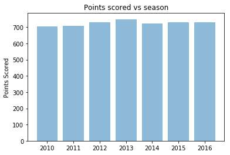

```python
objects = ('2010', '2011', '2012', '2013', '2014', '2015','2016')
y_pos = np.arange(len(objects))
plt.bar(y_pos, dfDate['PA'], align='center', alpha=0.5)
plt.xticks(y_pos, objects)
plt.ylabel('Points Scored')
plt.title('Points scored vs season')
plt.show()
```

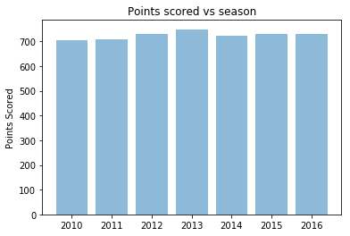

```python
objects = ('2010', '2011', '2012', '2013', '2014', '2015','2016')
y_pos = np.arange(len(objects))
plt.bar(y_pos, dfDate['PF'], align='center', alpha=0.5)
plt.xticks(y_pos, objects)
plt.ylabel('Points Scored')
plt.title('Points scored vs season')
plt.show()
```

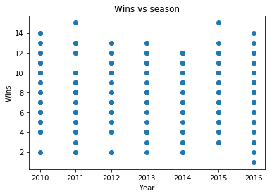

```python
plt.scatter(df['year'], df['W'])
plt.title('Wins vs season')
plt.ylabel('Wins')
plt.xlabel('Year')
plt.show()
```

The above two graphs both display that time, in general, does not affect statistics in the NFL. The first graph shows that the total points scored across the league has been consistent for the last 7 years. The first bar graph represents points allowed where the biggest differential between two years was around 700 points which is NOT significant. There are 32 teams in the league and all 32 teams play 16 games, thus for each year there are 512 inputs into points allowed. A difference of 700 points in a season just means that teams tended to score around one more point on average for games in that season. One point in football is not significant. The second bar graph is based on the total points for per season, again we do not see a major difference over time.

The scatter plot shows the number of wins by each team for each year. The reason that each year does not have 32 dots is that teams overlap with the number of wins. This graph shows us that time does not have an effect on the range or number of wins in an NFL season.

Now that we have shown time is not a major factor. Lets see if any of the data correlates well with number of wins per team.

```
Point for correlation coefficient with wins: 0.509111568398
```

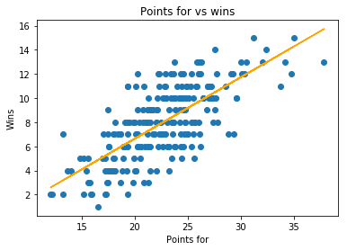

```python
# Plot
plt.scatter(df['PF'], df['W'])
plt.title('Points for vs wins')
plt.xlabel('Points for')
plt.ylabel('Wins')
fit = np.polyfit(df['PF'], df['W'], 1)
print("Point for correlation coefficient with wins:", fit[0])
plt.plot(df['PF'],fit[0]*df['PF']+fit[1], color='orange')
plt.show()
```

```
Points allowed correlation coefficient with respect to wins: -0.596375922075
```

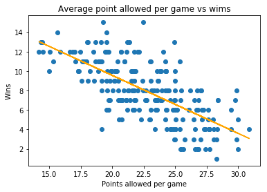

```python
# Plot
plt.scatter(df['PA'], df['W'])
plt.title('Average point allowed per game vs wims')
plt.xlabel('Points allowed per game')
plt.ylabel('Wins')
fit = np.polyfit(df['PA'], df['W'], 1)
plt.plot(df['PA'],fit[0]*df['PA']+fit[1], color='orange')
print("Points allowed correlation coefficient with respect to wins:", fit[0])
plt.show()
```

```
Point differential correlation coefficient with respect to wins: 0.0283374658617
```

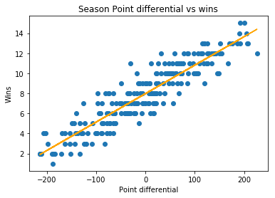

```python
# Plot
plt.scatter(df['PD'], df['W'])
plt.title('Season Point differential vs wins')
plt.xlabel('Point differential')
plt.ylabel('Wins')
fit = np.polyfit(df['PD'], df['W'], 1)
print("Point differential correlation coefficient with respect to wins:", fit[0])
plt.plot(df['PD'],fit[0]*df['PD']+fit[1], color='orange')
plt.show()
```

```
Margin of Victory correlation coefficient with respect to wins: 0.453039969914
```

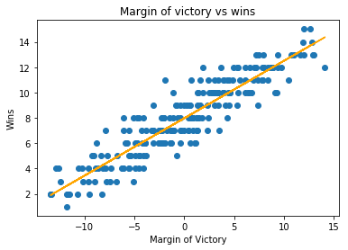

```python
# Plot
plt.scatter(df['MoV'], df['W'])
plt.title('Margin of victory vs wins')
plt.xlabel('Margin of Victory')
plt.ylabel('Wins')
fit = np.polyfit(df['MoV'], df['W'], 1)
plt.plot(df['MoV'],fit[0]*df['MoV']+fit[1], color='orange')
print("Margin of Victory correlation coefficient with respect to wins:", fit[0])
plt.show()
```

```
SoS correlation coefficient with respect to wins: -0.27803456065
```

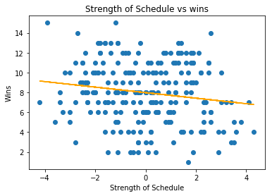

```python
# Plot
plt.scatter(df['SoS'], df['W'])
plt.title('Strength of Schedule vs wins')
plt.xlabel('Strength of Schedule')
plt.ylabel('Wins')
fit = np.polyfit(df['SoS'], df['W'], 1)
plt.plot(df['SoS'],fit[0]*df['SoS']+fit[1], color='orange')
print("SoS correlation coefficient with respect to wins:", fit[0])
plt.show()
```

```
SRS correlation coefficient with respect to wins: 0.430866691646
```

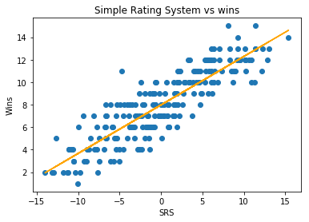

```python
# Plot
plt.scatter(df['SRS'], df['W'])
plt.title('Simple Rating System vs wins')
plt.xlabel('SRS')
plt.ylabel('Wins')
fit = np.polyfit(df['SRS'], df['W'], 1)
plt.plot(df['SRS'],fit[0]*df['SRS']+fit[1], color='orange')
print("SRS correlation coefficient with respect to wins:", fit[0])
plt.show()
```

```
OSRS correlation coefficient with respect to wins: 0.511126028684
```

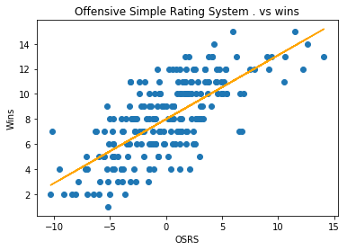

```python
# Plot
plt.scatter(df['OSRS'], df['W'])
plt.title('Offensive Simple Rating System . vs wins')
plt.xlabel('OSRS')
plt.ylabel('Wins')
fit = np.polyfit(df['OSRS'], df['W'], 1)
plt.plot(df['OSRS'],fit[0]*df['OSRS']+fit[1], color='orange')
print("OSRS correlation coefficient with respect to wins:", fit[0])
plt.show()
```

```
DSRS correlation coefficient with respect to wins: 0.55416188417
```

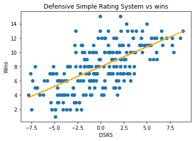

```python
# Plot
plt.scatter(df['DSRS'], df['W'])
plt.title('Defensive Simple Rating System vs wins')
plt.xlabel('DSRS')
plt.ylabel('Wins')
fit = np.polyfit(df['DSRS'], df['W'], 1)
plt.plot(df['DSRS'],fit[0]*df['DSRS']+fit[1], color='orange')
print("DSRS correlation coefficient with respect to wins:", fit[0])
plt.show()
```

Below we can see that combining points for and points allowed gives us a much better indication of the number of wins to expect from a team.

```python
print("The number of teams who gave up less then 20 ppg and scored more than 23 ppg: ", len(df[(df['PA']<=20) & (df['PF']>=23)].index))
print("The number of teams who gave up less then 20 ppg and scored more than 23 ppg and won atleast ten games: ",len(df[(df['PA']<=20) & (df['PF']>=23) & (df['W']>=10)].index))
```

```
The number of teams who gave up less then 20 ppg and scored more than 23 ppg:  34
The number of teams who gave up less then 20 ppg and scored more than 23 ppg and won atleast ten games:  33
```

```python
X = df[['PA']]
y = df['W']
model = sm.OLS(y, X).fit()
predictions = model.predict(X)
model.summary()
```

OLS Regression Results

| Dep. Variable: | W | R-squared: | 0.777 |
| --- | --- | --- | --- |
| Model: | OLS | Adj. R-squared: | 0.776 |
| Method: | Least Squares | F-statistic: | 777.8 |
| Date: | Sat, 16 Dec 2017 | Prob (F-statistic): | 1.19e-74 |
| Time: | 08:07:54 | Log-Likelihood: | -630.40 |
| No. Observations: | 224 | AIC: | 1263. |
| Df Residuals: | 223 | BIC: | 1266. |
| Df Model: | 1 |  |  |
| Covariance Type: | nonrobust |  |  |

|  | coef | std err | t | P>\|t\| | [0.025 | 0.975] |
| --- | --- | --- | --- | --- | --- | --- |
| PA | 0.3287 | 0.012 | 27.890 | 0.000 | 0.305 | 0.352 |

| Omnibus: | 18.028 | Durbin-Watson: | 1.946 |
| --- | --- | --- | --- |
| Prob(Omnibus): | 0.000 | Jarque-Bera (JB): | 6.566 |
| Skew: | -0.069 | Prob(JB): | 0.0375 |
| Kurtosis: | 2.173 | Cond. No. | 1.00 |

The OLS above points allowed is the only factor used to determine wins there is an R-squared value of .77 and an F-statistic of 777.8.

The OLS below the six values that had significant correlation coefficients are used and there is an R-squared value of .98 and an F-statistic of 1756. Clearly using more than one of our Statists correlates much better in determining the numbers of wins.

Intro to OLS: http://www.sfu.ca/~pendakur/teaching/econ836/intro_to_OLS_revised.pdf

```python
X = df[['PA', 'PF','MoV','SRS','OSRS','DSRS']]
y = df['W']
model = sm.OLS(y, X).fit()
predictions = model.predict(X)
model.summary()
```

OLS Regression Results

| Dep. Variable: | W | R-squared: | 0.980 |
| --- | --- | --- | --- |
| Model: | OLS | Adj. R-squared: | 0.979 |
| Method: | Least Squares | F-statistic: | 1756. |
| Date: | Sat, 16 Dec 2017 | Prob (F-statistic): | 1.64e-181 |
| Time: | 08:08:47 | Log-Likelihood: | -361.91 |
| No. Observations: | 224 | AIC: | 735.8 |
| Df Residuals: | 218 | BIC: | 756.3 |
| Df Model: | 6 |  |  |
| Covariance Type: | nonrobust |  |  |

|  | coef | std err | t | P>\|t\| | [0.025 | 0.975] |
| --- | --- | --- | --- | --- | --- | --- |
| PA | -5.9971 | 2.882 | -2.081 | 0.039 | -11.676 | -0.318 |
| PF | 6.3482 | 2.881 | 2.203 | 0.029 | 0.670 | 12.027 |
| MoV | -5.6741 | 2.881 | -1.970 | 0.050 | -11.352 | 0.004 |
| SRS | -0.2278 | 1.637 | -0.139 | 0.889 | -3.454 | 2.999 |
| OSRS | -0.0185 | 1.635 | -0.011 | 0.991 | -3.241 | 3.204 |
| DSRS | 0.4097 | 1.633 | 0.251 | 0.802 | -2.809 | 3.629 |

| Omnibus: | 1.260 | Durbin-Watson: | 1.887 |
| --- | --- | --- | --- |
| Prob(Omnibus): | 0.533 | Jarque-Bera (JB): | 1.329 |
| Skew: | 0.128 | Prob(JB): | 0.514 |
| Kurtosis: | 2.722 | Cond. No. | 1.96e+03 |

## Machine Learning

Choosing our Hypothesis: In this section we are going to use machine learning to try and predict the number of wins by a team in an season. These predictions will be based off points for, points allowed, margin of victory, simple rating system, offensive SRS, and defensive SRS. The first machine learning algorithim will take these six statistics and output a predicted number of wins. This will be done by supervised learning which is the principle of splitting our data into a training set and a test set. We train the model with the test set by giving the model our six stats along with the win totals so it can determine how the stats correlate with wins. Then for the test set the model will only see the six stats and give a prediction for the number of wins. Then we will access the accuracy of our prediction against the actual values. The hypothesis is that the six values can accurately predict the number of wins by a team in a season.

### 1. Linear Regression

```python
Test = df[['PF','PA','MoV','SRS','OSRS','DSRS']]
X = np.array(Test)
y = np.array(df['W'])
X_train, X_test, y_train, y_test = train_test_split(X, y, test_size=0.25)
# the shapes need to be the same in order to test.
print (X_train.shape, y_train.shape)
print (X_test.shape, y_test.shape)
```

```
(168, 6) (168,)
(56, 6) (56,)
```

```python
lm = LinearRegression()
model=lm.fit(X_train,y_train)
```

```python
predictions= lm.predict(X_test)
#Accuracy of the prediction
confidence = lm.score(X_test, y_test)
for num in range(0,25):
    print("Predicted wins:",round(predictions[num],2), "Actual wins", y_test[num])
print('This is the prediction accuracy',confidence)
```

```
Predicted wins: 3.76 Actual wins 4.0
Predicted wins: 13.62 Actual wins 13.0
Predicted wins: 12.41 Actual wins 12.0
Predicted wins: 11.95 Actual wins 12.0
Predicted wins: 8.01 Actual wins 7.0
Predicted wins: 8.33 Actual wins 8.0
Predicted wins: 3.62 Actual wins 3.0
Predicted wins: 4.99 Actual wins 5.0
Predicted wins: 2.74 Actual wins 2.0
Predicted wins: 7.11 Actual wins 6.0
Predicted wins: 6.32 Actual wins 6.0
Predicted wins: 7.87 Actual wins 9.0
Predicted wins: 5.9 Actual wins 4.0
Predicted wins: 5.93 Actual wins 8.0
Predicted wins: 11.82 Actual wins 12.0
Predicted wins: 5.52 Actual wins 3.0
Predicted wins: 7.58 Actual wins 6.0
Predicted wins: 7.19 Actual wins 8.0
Predicted wins: 5.89 Actual wins 4.0
Predicted wins: 6.14 Actual wins 6.0
Predicted wins: 11.77 Actual wins 9.0
Predicted wins: 3.91 Actual wins 3.0
Predicted wins: 9.52 Actual wins 11.0
Predicted wins: 10.05 Actual wins 11.0
Predicted wins: 9.63 Actual wins 7.0
This is the prediction accuracy 0.831117098865
```

Above we can see that the number of predicted wins and the actual amount of wins for the first twenty five values in our test set. The model will give a float number when in reality the number of wins by a team is an integer. From our prediction accuracy we can see that our model is relativly accurate in predicting the number of wins by a team based on the statistics. Below is a graph visualizing Actual wins versus predicted wins.

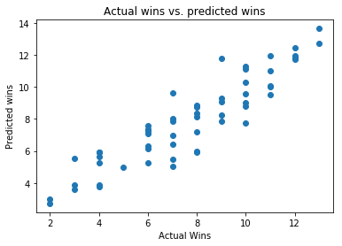

```python
plt.title('Actual wins vs. predicted wins')
plt.scatter(y_test,predictions)
plt.xlabel('Actual Wins', size=10)
plt.ylabel('Predicted wins', size=10)
plt.show()
```

Next we will do ten fold cross validation to ensure that we did not overfit the training data. In cross-validation we partition the original data into ten equal size subsamples. Of the ten samples one is used as testing or validation of the model. The remaining 9 subsamples are used as training data. This process is then repeated ten times with each subsample used once as the testing data. We will then average the ten results to produce a single number to show the accuracy of our model.

To learn more about overfitting: https://elitedatascience.com/overfitting-in-machine-learning

To learn more about cross validation: http://scikitlearn.org/stable/modules/generated/sklearn.model_selection.KFold.html.

```python
#Perform 10 fold Cross Validation (KFold)
scores=cross_val_score(model,X,y,cv=10)
print ('Cross Validated Scores',scores)
# Make Cross Validated predictions
predictions2=cross_val_predict(model,X,y,cv=10)
#Check the R2- the proportion of variance in the dependent variable explained by the predictors
accuracy = metrics.r2_score(y,predictions2)
print ('This is R2',accuracy)
```

[output not shown]

```
Cross Validated Scores [ 0.69624069  0.85549074  0.87417547  0.89797574  0.83982436  0.90231684
  0.82477101  0.75083914  0.90521053  0.76677199]
```

### Hypothesis testing

From our cross validation scores we can see that our model is not perfect at predicting the number of wins, but still does a decent job. The question we are seeking to answer is if there is a relationship between our six stats and the number of wins per team. To answer this we will use our R2 value. The R2 value compares the variation for all win values sharing common X values with variation from the prediction. The best possible R2 value is 1, while the worst would be 0. Our R2 value of .83 is very good and it means that our data explains most of the error found in our model.

For more on R2 values: http://scikit-learn.org/stable/modules/generated/sklearn.metrics.r2_score.html

### More machine learning

For this second type of machine learning we will doing classification. This means we will take in data and try to predict what category that data belongs in. For our model we will be doing whether or not an NFL team will be in playoff contention. I have defined contention as having 9 or more wins, as this is typically the minimum number of wins that it takes to make the playoffs. We will be using a Gaussian Naive Bayes classifier.

Intro to Gaussian Naive Bayes: http://scikit-learn.org/stable/modules/generated/sklearn.naive_bayes.GaussianNB.html

```python
df['playoff contnetion'] = df['W']>=9
df.head()
```

|  | Tm | W | L | T | W-L% | PF | PA | PD | MoV | SoS | SRS | OSRS | DSRS | year | playoff contnetion |
| --- | --- | --- | --- | --- | --- | --- | --- | --- | --- | --- | --- | --- | --- | --- | --- |
| 1 | New England Patriots* | 14.0 | 2.0 | 0.0 | 0.875 | 27.5625 | 15.6250 | 191.0 | 11.9 | -2.7 | 9.3 | 4.3 | 5.0 | 2016 | True |
| 2 | Miami Dolphins+ | 10.0 | 6.0 | 0.0 | 0.625 | 22.6875 | 23.7500 | -17.0 | -1.1 | -1.3 | -2.4 | -0.6 | -1.8 | 2016 | True |
| 3 | Buffalo Bills | 7.0 | 9.0 | 0.0 | 0.438 | 24.9375 | 23.6250 | 21.0 | 1.3 | -1.6 | -0.3 | 1.8 | -2.2 | 2016 | False |
| 4 | New York Jets | 5.0 | 11.0 | 0.0 | 0.313 | 17.1875 | 25.5625 | -134.0 | -8.4 | -0.1 | -8.5 | -5.5 | -3.0 | 2016 | False |
| 5 | Pittsburgh Steelers* | 11.0 | 5.0 | 0.0 | 0.688 | 24.9375 | 20.4375 | 72.0 | 4.5 | 0.2 | 4.7 | 2.8 | 2.0 | 2016 | True |

```python
Test = df[['PF','PA','MoV','SoS','SRS','OSRS','DSRS']]
X = np.array(Test)
y = np.array(df['playoff contnetion'])
train, test, train_labels, test_labels = train_test_split(X,
                                                          y,
                                                          test_size=0.25,
                                                          random_state=42)
```

```python
# Initialize our classifier
gnb = GaussianNB()
# Train our classifier
model = gnb.fit(train, train_labels)
```

```python
# Make predictions
preds = gnb.predict(test)
print(preds)
```

```
[False  True False  True False False  True  True  True  True False False
 False False False  True False False  True False  True  True False False
 False False  True False  True False  True  True  True  True  True False
 False False False  True  True  True False  True  True False  True  True
  True False False  True False  True False  True]
```

```python
scores = cross_val_score(gnb, test, test_labels, cv=10)
print("Accuracy scoores for cross validation: ", scores)
# Evaluate accuracy
print("Accuracy score:", accuracy_score(test_labels, preds))
```

```
Accuracy scoores for cross validation:  [ 0.71428571  1.          0.83333333  0.83333333  0.83333333  0.8         1.
  1.          0.8         1.        ]
Accuracy score: 0.875
```

This classifier is relatively accurate at predicting whether or not a team will be in playoff contention. In the machine learning section we have seen how we can train models to take input and use it to either predict the number of wins by a team, or it can classify a team into a bucket based.

# Conclusion

Using principles of data science and tools in python we were able to reasonably predict the number of wins a team would end up with in a season. We were also able to predict if a team would end the season in playoff contention, defined as having 9 or more wins. More complex data science ventures can be done in the nfl, such as predicting outcomes of individual games. With different data, but similar methodology one could try and predict how successful a certain play is going to be in a given game.